# Risk Factor Analysis

## Outcome Variable

**Outcome Variable:** sstunted

## Predictor Variables

**Intervention Variable:** tr

**Adjustment Set:**

unadjusted

## Stratifying Variables

The analysis was stratified on these variable(s):

- agecat
- studyid
- country
- intXhfoodsec

## Data Summary

| agecat | studyid | country | intXhfoodsec | sstunted | n_cell | n |
| --- | --- | --- | --- | --- | --- | --- |
| Birth | iLiNS_DYADM_LNS | MALAWI | Food Insecure_Birth | 0 | 0 | 1 |
| Birth | iLiNS_DYADM_LNS | MALAWI | Food Insecure_Birth | 1 | 1 | 1 |
| Birth | ki1148112-iLiNS-DYAD-M | MALAWI | Food Insecure_Birth | 0 | 0 | 1 |
| Birth | ki1148112-iLiNS-DYAD-M | MALAWI | Food Insecure_Birth | 1 | 1 | 1 |
| Birth | kiGH5241-JiVitA-3 | BANGLADESH | Food Secure_Birth | 0 | 10962 | 11994 |
| Birth | kiGH5241-JiVitA-3 | BANGLADESH | Food Secure_Birth | 1 | 1032 | 11994 |
| Birth | kiGH5241-JiVitA-3 | BANGLADESH | Mildly Food Insecure_Birth | 0 | 7826 | 8670 |
| Birth | kiGH5241-JiVitA-3 | BANGLADESH | Mildly Food Insecure_Birth | 1 | 844 | 8670 |
| Birth | kiGH5241-JiVitA-3 | BANGLADESH | Food Insecure_Birth | 0 | 4074 | 4546 |
| Birth | kiGH5241-JiVitA-3 | BANGLADESH | Food Insecure_Birth | 1 | 472 | 4546 |
| Birth | kiGH5241-JiVitA-4 | BANGLADESH | Food Secure_Birth | 0 | 734 | 792 |
| Birth | kiGH5241-JiVitA-4 | BANGLADESH | Food Secure_Birth | 1 | 58 | 792 |
| Birth | kiGH5241-JiVitA-4 | BANGLADESH | Mildly Food Insecure_Birth | 0 | 560 | 618 |
| Birth | kiGH5241-JiVitA-4 | BANGLADESH | Mildly Food Insecure_Birth | 1 | 58 | 618 |
| Birth | kiGH5241-JiVitA-4 | BANGLADESH | Food Insecure_Birth | 0 | 216 | 228 |
| Birth | kiGH5241-JiVitA-4 | BANGLADESH | Food Insecure_Birth | 1 | 12 | 228 |
| 6 months | iLiNS_DYADM_LNS | MALAWI | Food Secure_6 months | 0 | 119 | 122 |
| 6 months | iLiNS_DYADM_LNS | MALAWI | Food Secure_6 months | 1 | 3 | 122 |
| 6 months | iLiNS_DYADM_LNS | MALAWI | Mildly Food Insecure_6 months | 0 | 85 | 89 |
| 6 months | iLiNS_DYADM_LNS | MALAWI | Mildly Food Insecure_6 months | 1 | 4 | 89 |
| 6 months | iLiNS_DYADM_LNS | MALAWI | Food Insecure_6 months | 0 | 196 | 210 |
| 6 months | iLiNS_DYADM_LNS | MALAWI | Food Insecure_6 months | 1 | 14 | 210 |
| 6 months | ki1000110-WASH-Bangladesh | BANGLADESH | Food Secure_6 months | 0 | 477 | 495 |
| 6 months | ki1000110-WASH-Bangladesh | BANGLADESH | Food Secure_6 months | 1 | 18 | 495 |
| 6 months | ki1000110-WASH-Bangladesh | BANGLADESH | Mildly Food Insecure_6 months | 0 | 46 | 46 |
| 6 months | ki1000110-WASH-Bangladesh | BANGLADESH | Mildly Food Insecure_6 months | 1 | 0 | 46 |
| 6 months | ki1000110-WASH-Bangladesh | BANGLADESH | Food Insecure_6 months | 0 | 131 | 141 |
| 6 months | ki1000110-WASH-Bangladesh | BANGLADESH | Food Insecure_6 months | 1 | 10 | 141 |
| 6 months | ki1148112-iLiNS-DOSE | MALAWI | Food Secure_6 months | 0 | 383 | 400 |
| 6 months | ki1148112-iLiNS-DOSE | MALAWI | Food Secure_6 months | 1 | 17 | 400 |

[output cut: 58 more lines]

The following strata were considered:

- agecat: 24 months, studyid: iLiNS_DYADM_LNS, country: MALAWI, intXhfoodsec: Food Insecure_24 months
- agecat: 24 months, studyid: iLiNS_DYADM_LNS, country: MALAWI, intXhfoodsec: Food Secure_24 months
- agecat: 24 months, studyid: iLiNS_DYADM_LNS, country: MALAWI, intXhfoodsec: Mildly Food Insecure_24 months
- agecat: 24 months, studyid: ki1000110-WASH-Bangladesh, country: BANGLADESH, intXhfoodsec: Food Insecure_24 months
- agecat: 24 months, studyid: ki1000110-WASH-Bangladesh, country: BANGLADESH, intXhfoodsec: Food Secure_24 months
- agecat: 24 months, studyid: ki1000110-WASH-Bangladesh, country: BANGLADESH, intXhfoodsec: Mildly Food Insecure_24 months
- agecat: 24 months, studyid: ki1148112-iLiNS-DOSE, country: MALAWI, intXhfoodsec: Food Insecure_24 months
- agecat: 24 months, studyid: ki1148112-iLiNS-DOSE, country: MALAWI, intXhfoodsec: Food Secure_24 months
- agecat: 24 months, studyid: ki1148112-iLiNS-DOSE, country: MALAWI, intXhfoodsec: Mildly Food Insecure_24 months
- agecat: 24 months, studyid: ki1148112-iLiNS-DYAD-M, country: MALAWI, intXhfoodsec: Food Insecure_24 months
- agecat: 24 months, studyid: ki1148112-iLiNS-DYAD-M, country: MALAWI, intXhfoodsec: Food Secure_24 months
- agecat: 24 months, studyid: ki1148112-iLiNS-DYAD-M, country: MALAWI, intXhfoodsec: Mildly Food Insecure_24 months
- agecat: 24 months, studyid: kiGH5241-JiVitA-3, country: BANGLADESH, intXhfoodsec: Food Insecure_24 months
- agecat: 24 months, studyid: kiGH5241-JiVitA-3, country: BANGLADESH, intXhfoodsec: Food Secure_24 months
- agecat: 24 months, studyid: kiGH5241-JiVitA-3, country: BANGLADESH, intXhfoodsec: Mildly Food Insecure_24 months
- agecat: 24 months, studyid: kiGH5241-JiVitA-4, country: BANGLADESH, intXhfoodsec: Food Insecure_24 months
- agecat: 24 months, studyid: kiGH5241-JiVitA-4, country: BANGLADESH, intXhfoodsec: Food Secure_24 months
- agecat: 24 months, studyid: kiGH5241-JiVitA-4, country: BANGLADESH, intXhfoodsec: Mildly Food Insecure_24 months
- agecat: 6 months, studyid: iLiNS_DYADM_LNS, country: MALAWI, intXhfoodsec: Food Insecure_6 months
- agecat: 6 months, studyid: iLiNS_DYADM_LNS, country: MALAWI, intXhfoodsec: Food Secure_6 months
- agecat: 6 months, studyid: iLiNS_DYADM_LNS, country: MALAWI, intXhfoodsec: Mildly Food Insecure_6 months
- agecat: 6 months, studyid: ki1000110-WASH-Bangladesh, country: BANGLADESH, intXhfoodsec: Food Insecure_6 months
- agecat: 6 months, studyid: ki1000110-WASH-Bangladesh, country: BANGLADESH, intXhfoodsec: Food Secure_6 months
- agecat: 6 months, studyid: ki1000110-WASH-Bangladesh, country: BANGLADESH, intXhfoodsec: Mildly Food Insecure_6 months
- agecat: 6 months, studyid: ki1148112-iLiNS-DOSE, country: MALAWI, intXhfoodsec: Food Insecure_6 months
- agecat: 6 months, studyid: ki1148112-iLiNS-DOSE, country: MALAWI, intXhfoodsec: Food Secure_6 months
- agecat: 6 months, studyid: ki1148112-iLiNS-DOSE, country: MALAWI, intXhfoodsec: Mildly Food Insecure_6 months
- agecat: 6 months, studyid: ki1148112-iLiNS-DYAD-M, country: MALAWI, intXhfoodsec: Food Insecure_6 months
- agecat: 6 months, studyid: ki1148112-iLiNS-DYAD-M, country: MALAWI, intXhfoodsec: Food Secure_6 months
- agecat: 6 months, studyid: ki1148112-iLiNS-DYAD-M, country: MALAWI, intXhfoodsec: Mildly Food Insecure_6 months
- agecat: 6 months, studyid: kiGH5241-JiVitA-3, country: BANGLADESH, intXhfoodsec: Food Insecure_6 months
- agecat: 6 months, studyid: kiGH5241-JiVitA-3, country: BANGLADESH, intXhfoodsec: Food Secure_6 months
- agecat: 6 months, studyid: kiGH5241-JiVitA-3, country: BANGLADESH, intXhfoodsec: Mildly Food Insecure_6 months
- agecat: 6 months, studyid: kiGH5241-JiVitA-4, country: BANGLADESH, intXhfoodsec: Food Insecure_6 months
- agecat: 6 months, studyid: kiGH5241-JiVitA-4, country: BANGLADESH, intXhfoodsec: Food Secure_6 months
- agecat: 6 months, studyid: kiGH5241-JiVitA-4, country: BANGLADESH, intXhfoodsec: Mildly Food Insecure_6 months
- agecat: Birth, studyid: iLiNS_DYADM_LNS, country: MALAWI, intXhfoodsec: Food Insecure_Birth
- agecat: Birth, studyid: ki1148112-iLiNS-DYAD-M, country: MALAWI, intXhfoodsec: Food Insecure_Birth
- agecat: Birth, studyid: kiGH5241-JiVitA-3, country: BANGLADESH, intXhfoodsec: Food Insecure_Birth
- agecat: Birth, studyid: kiGH5241-JiVitA-3, country: BANGLADESH, intXhfoodsec: Food Secure_Birth
- agecat: Birth, studyid: kiGH5241-JiVitA-3, country: BANGLADESH, intXhfoodsec: Mildly Food Insecure_Birth
- agecat: Birth, studyid: kiGH5241-JiVitA-4, country: BANGLADESH, intXhfoodsec: Food Insecure_Birth
- agecat: Birth, studyid: kiGH5241-JiVitA-4, country: BANGLADESH, intXhfoodsec: Food Secure_Birth
- agecat: Birth, studyid: kiGH5241-JiVitA-4, country: BANGLADESH, intXhfoodsec: Mildly Food Insecure_Birth

### Dropped Strata

Some strata were dropped due to rare outcomes:

- agecat: Birth, studyid: iLiNS_DYADM_LNS, country: MALAWI, intXhfoodsec: Food Insecure_Birth
- agecat: Birth, studyid: ki1148112-iLiNS-DYAD-M, country: MALAWI, intXhfoodsec: Food Insecure_Birth
- agecat: 6 months, studyid: iLiNS_DYADM_LNS, country: MALAWI, intXhfoodsec: Food Secure_6 months
- agecat: 6 months, studyid: iLiNS_DYADM_LNS, country: MALAWI, intXhfoodsec: Mildly Food Insecure_6 months
- agecat: 6 months, studyid: ki1000110-WASH-Bangladesh, country: BANGLADESH, intXhfoodsec: Mildly Food Insecure_6 months
- agecat: 24 months, studyid: iLiNS_DYADM_LNS, country: MALAWI, intXhfoodsec: Food Secure_24 months
- agecat: 24 months, studyid: iLiNS_DYADM_LNS, country: MALAWI, intXhfoodsec: Mildly Food Insecure_24 months
- agecat: 24 months, studyid: iLiNS_DYADM_LNS, country: MALAWI, intXhfoodsec: Food Insecure_24 months
- agecat: 24 months, studyid: ki1148112-iLiNS-DYAD-M, country: MALAWI, intXhfoodsec: Food Secure_24 months
- agecat: 24 months, studyid: ki1148112-iLiNS-DYAD-M, country: MALAWI, intXhfoodsec: Mildly Food Insecure_24 months
- agecat: 24 months, studyid: ki1148112-iLiNS-DYAD-M, country: MALAWI, intXhfoodsec: Food Insecure_24 months

## Methods Detail

We’re interested in the causal parameters $E[Y_a]$ for all values of $a \in \mathcal{A}$. These parameters represent the mean outcome if, possibly contrary to fact, we intervened to set all units to have $A=a$. Under the randomization and positivity assumptions, these are identified by the statistical parameters $\psi_a=E_W[E_{Y|A,W}(Y|A=a,W)]$. In addition, we’re interested in the mean of $Y$, $E[Y]$ under no intervention (the observed mean). We will estimate these parameters by using SuperLearner to fit the relevant likelihood factors – $E_{Y|A,W}(Y|A=a,W)$ and $p(A=a|W)$, and then updating our likelihood fit using a joint TMLE.

For unadjusted analyses ($W=\{\}$), initial likelihoods were estimated using Lrnr_glm to estimate the simple $E(Y|A)$ and Lrnr_mean to estimate $p(A)$. For adjusted analyses, a small library containing Lrnr_glmnet, Lrnr_xgboost, and Lrnr_mean was used.

Having estimated these parameters, we will then use the delta method to estimate relative risks and attributable risks relative to a prespecified baseline level of $A$.

# Results Detail

## Results Plots

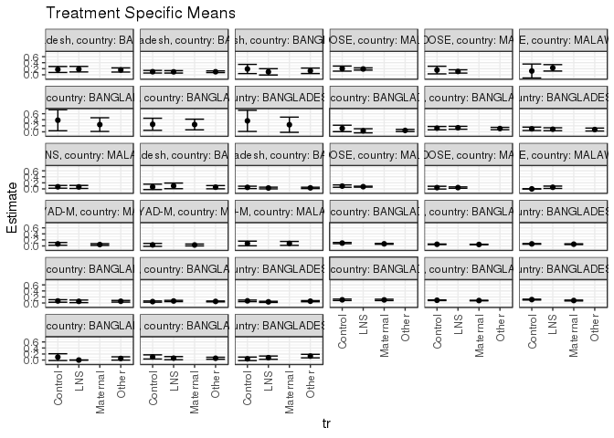

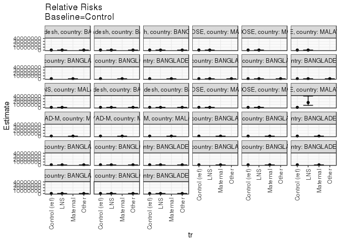

[figure not shown]

[figure not shown]

## Results Table

### Parameter: TSM

| agecat | studyid | country | intXhfoodsec | intervention_level | baseline_level | estimate | ci_lower | ci_upper |
| --- | --- | --- | --- | --- | --- | --- | --- | --- |
| Birth | kiGH5241-JiVitA-3 | BANGLADESH | Food Secure_Birth | Control | NA | 0.0908481 | 0.0789573 | 0.1027390 |
| Birth | kiGH5241-JiVitA-3 | BANGLADESH | Food Secure_Birth | Maternal | NA | 0.0812873 | 0.0706288 | 0.0919459 |
| Birth | kiGH5241-JiVitA-3 | BANGLADESH | Mildly Food Insecure_Birth | Control | NA | 0.1124535 | 0.0969706 | 0.1279365 |
| Birth | kiGH5241-JiVitA-3 | BANGLADESH | Mildly Food Insecure_Birth | Maternal | NA | 0.0824553 | 0.0675049 | 0.0974058 |
| Birth | kiGH5241-JiVitA-3 | BANGLADESH | Food Insecure_Birth | Control | NA | 0.1051237 | 0.0813204 | 0.1289269 |
| Birth | kiGH5241-JiVitA-3 | BANGLADESH | Food Insecure_Birth | Maternal | NA | 0.1025416 | 0.0801969 | 0.1248863 |
| Birth | kiGH5241-JiVitA-4 | BANGLADESH | Food Secure_Birth | Control | NA | 0.1034483 | 0.0341329 | 0.1727637 |
| Birth | kiGH5241-JiVitA-4 | BANGLADESH | Food Secure_Birth | LNS | NA | 0.0625000 | 0.0110526 | 0.1139474 |
| Birth | kiGH5241-JiVitA-4 | BANGLADESH | Food Secure_Birth | Other | NA | 0.0595238 | 0.0265153 | 0.0925323 |
| Birth | kiGH5241-JiVitA-4 | BANGLADESH | Mildly Food Insecure_Birth | Control | NA | 0.0400000 | -0.0179136 | 0.0979136 |
| Birth | kiGH5241-JiVitA-4 | BANGLADESH | Mildly Food Insecure_Birth | LNS | NA | 0.0786517 | 0.0245276 | 0.1327758 |
| Birth | kiGH5241-JiVitA-4 | BANGLADESH | Mildly Food Insecure_Birth | Other | NA | 0.1310345 | 0.0725355 | 0.1895335 |
| Birth | kiGH5241-JiVitA-4 | BANGLADESH | Food Insecure_Birth | Control | NA | 0.0967742 | -0.0152902 | 0.2088386 |
| Birth | kiGH5241-JiVitA-4 | BANGLADESH | Food Insecure_Birth | LNS | NA | 0.0000000 | 0.0000000 | 0.0000000 |
| Birth | kiGH5241-JiVitA-4 | BANGLADESH | Food Insecure_Birth | Other | NA | 0.0526316 | -0.0016325 | 0.1068956 |
| 6 months | iLiNS_DYADM_LNS | MALAWI | Food Insecure_6 months | Control | NA | 0.0683761 | 0.0225340 | 0.1142181 |
| 6 months | iLiNS_DYADM_LNS | MALAWI | Food Insecure_6 months | LNS | NA | 0.0645161 | 0.0144671 | 0.1145651 |
| 6 months | ki1000110-WASH-Bangladesh | BANGLADESH | Food Secure_6 months | Control | NA | 0.0504202 | 0.0110668 | 0.0897735 |
| 6 months | ki1000110-WASH-Bangladesh | BANGLADESH | Food Secure_6 months | LNS | NA | 0.0294118 | 0.0009871 | 0.0578365 |
| 6 months | ki1000110-WASH-Bangladesh | BANGLADESH | Food Secure_6 months | Other | NA | 0.0333333 | 0.0106002 | 0.0560665 |
| 6 months | ki1000110-WASH-Bangladesh | BANGLADESH | Food Insecure_6 months | Control | NA | 0.0666667 | -0.0229122 | 0.1562456 |
| 6 months | ki1000110-WASH-Bangladesh | BANGLADESH | Food Insecure_6 months | LNS | NA | 0.1000000 | 0.0066993 | 0.1933007 |
| 6 months | ki1000110-WASH-Bangladesh | BANGLADESH | Food Insecure_6 months | Other | NA | 0.0563380 | 0.0025143 | 0.1101617 |
| 6 months | ki1148112-iLiNS-DOSE | MALAWI | Food Secure_6 months | Control | NA | 0.0410959 | -0.0044991 | 0.0866909 |
| 6 months | ki1148112-iLiNS-DOSE | MALAWI | Food Secure_6 months | LNS | NA | 0.0428135 | 0.0208447 | 0.0647822 |
| 6 months | ki1148112-iLiNS-DOSE | MALAWI | Mildly Food Insecure_6 months | Control | NA | 0.0000000 | 0.0000000 | 0.0000000 |
| 6 months | ki1148112-iLiNS-DOSE | MALAWI | Mildly Food Insecure_6 months | LNS | NA | 0.0538462 | 0.0149150 | 0.0927773 |
| 6 months | ki1148112-iLiNS-DOSE | MALAWI | Food Insecure_6 months | Control | NA | 0.0922330 | 0.0527035 | 0.1317625 |
| 6 months | ki1148112-iLiNS-DOSE | MALAWI | Food Insecure_6 months | LNS | NA | 0.0729572 | 0.0570530 | 0.0888614 |
| 6 months | ki1148112-iLiNS-DYAD-M | MALAWI | Food Secure_6 months | Control | NA | 0.0350877 | -0.0128122 | 0.0829877 |
| 6 months | ki1148112-iLiNS-DYAD-M | MALAWI | Food Secure_6 months | Maternal | NA | 0.0322581 | 0.0010735 | 0.0634426 |
| 6 months | ki1148112-iLiNS-DYAD-M | MALAWI | Mildly Food Insecure_6 months | Control | NA | 0.0816327 | 0.0046474 | 0.1586179 |
| 6 months | ki1148112-iLiNS-DYAD-M | MALAWI | Mildly Food Insecure_6 months | Maternal | NA | 0.0845070 | 0.0195375 | 0.1494766 |
| 6 months | ki1148112-iLiNS-DYAD-M | MALAWI | Food Insecure_6 months | Control | NA | 0.0683761 | 0.0225747 | 0.1141775 |
| 6 months | ki1148112-iLiNS-DYAD-M | MALAWI | Food Insecure_6 months | Maternal | NA | 0.0460830 | 0.0181450 | 0.0740209 |
| 6 months | kiGH5241-JiVitA-3 | BANGLADESH | Food Secure_6 months | Control | NA | 0.0551633 | 0.0477774 | 0.0625493 |
| 6 months | kiGH5241-JiVitA-3 | BANGLADESH | Food Secure_6 months | Maternal | NA | 0.0486358 | 0.0420183 | 0.0552534 |
| 6 months | kiGH5241-JiVitA-3 | BANGLADESH | Mildly Food Insecure_6 months | Control | NA | 0.0682190 | 0.0577282 | 0.0787098 |
| 6 months | kiGH5241-JiVitA-3 | BANGLADESH | Mildly Food Insecure_6 months | Maternal | NA | 0.0583142 | 0.0454386 | 0.0711898 |
| 6 months | kiGH5241-JiVitA-3 | BANGLADESH | Food Insecure_6 months | Control | NA | 0.0948529 | 0.0747558 | 0.1149501 |
| 6 months | kiGH5241-JiVitA-3 | BANGLADESH | Food Insecure_6 months | Maternal | NA | 0.0704074 | 0.0564261 | 0.0843888 |
| 6 months | kiGH5241-JiVitA-4 | BANGLADESH | Food Secure_6 months | Control | NA | 0.0461165 | 0.0260541 | 0.0661789 |
| 6 months | kiGH5241-JiVitA-4 | BANGLADESH | Food Secure_6 months | LNS | NA | 0.0661710 | 0.0448521 | 0.0874899 |
| 6 months | kiGH5241-JiVitA-4 | BANGLADESH | Food Secure_6 months | Other | NA | 0.0528022 | 0.0381975 | 0.0674070 |
| 6 months | kiGH5241-JiVitA-4 | BANGLADESH | Mildly Food Insecure_6 months | Control | NA | 0.0717703 | 0.0458942 | 0.0976465 |
| 6 months | kiGH5241-JiVitA-4 | BANGLADESH | Mildly Food Insecure_6 months | LNS | NA | 0.0374732 | 0.0188645 | 0.0560819 |
| 6 months | kiGH5241-JiVitA-4 | BANGLADESH | Mildly Food Insecure_6 months | Other | NA | 0.0598991 | 0.0406354 | 0.0791628 |
| 6 months | kiGH5241-JiVitA-4 | BANGLADESH | Food Insecure_6 months | Control | NA | 0.0676471 | 0.0259522 | 0.1093420 |
| 6 months | kiGH5241-JiVitA-4 | BANGLADESH | Food Insecure_6 months | LNS | NA | 0.0551724 | 0.0131220 | 0.0972228 |
| 6 months | kiGH5241-JiVitA-4 | BANGLADESH | Food Insecure_6 months | Other | NA | 0.0574324 | 0.0296731 | 0.0851918 |
| 24 months | ki1000110-WASH-Bangladesh | BANGLADESH | Food Secure_24 months | Control | NA | 0.1010638 | 0.0579527 | 0.1441749 |
| 24 months | ki1000110-WASH-Bangladesh | BANGLADESH | Food Secure_24 months | LNS | NA | 0.0970874 | 0.0566320 | 0.1375428 |
| 24 months | ki1000110-WASH-Bangladesh | BANGLADESH | Food Secure_24 months | Other | NA | 0.1002227 | 0.0724299 | 0.1280156 |
| 24 months | ki1000110-WASH-Bangladesh | BANGLADESH | Mildly Food Insecure_24 months | Control | NA | 0.1923077 | 0.0401248 | 0.3444906 |
| 24 months | ki1000110-WASH-Bangladesh | BANGLADESH | Mildly Food Insecure_24 months | LNS | NA | 0.0967742 | -0.0077768 | 0.2013252 |
| 24 months | ki1000110-WASH-Bangladesh | BANGLADESH | Mildly Food Insecure_24 months | Other | NA | 0.1320755 | 0.0405071 | 0.2236438 |
| 24 months | ki1000110-WASH-Bangladesh | BANGLADESH | Food Insecure_24 months | Control | NA | 0.1754386 | 0.0764888 | 0.2743883 |
| 24 months | ki1000110-WASH-Bangladesh | BANGLADESH | Food Insecure_24 months | LNS | NA | 0.1857143 | 0.0944207 | 0.2770078 |
| 24 months | ki1000110-WASH-Bangladesh | BANGLADESH | Food Insecure_24 months | Other | NA | 0.1588785 | 0.0894643 | 0.2282927 |
| 24 months | ki1148112-iLiNS-DOSE | MALAWI | Food Secure_24 months | Control | NA | 0.1562500 | 0.0300498 | 0.2824502 |
| 24 months | ki1148112-iLiNS-DOSE | MALAWI | Food Secure_24 months | LNS | NA | 0.1102362 | 0.0555956 | 0.1648769 |
| 24 months | ki1148112-iLiNS-DOSE | MALAWI | Mildly Food Insecure_24 months | Control | NA | 0.1250000 | -0.1058512 | 0.3558512 |
| 24 months | ki1148112-iLiNS-DOSE | MALAWI | Mildly Food Insecure_24 months | LNS | NA | 0.2295082 | 0.1232074 | 0.3358090 |
| 24 months | ki1148112-iLiNS-DOSE | MALAWI | Food Insecure_24 months | Control | NA | 0.2045455 | 0.1201904 | 0.2889005 |
| 24 months | ki1148112-iLiNS-DOSE | MALAWI | Food Insecure_24 months | LNS | NA | 0.1920530 | 0.1557449 | 0.2283610 |
| 24 months | kiGH5241-JiVitA-3 | BANGLADESH | Food Secure_24 months | Control | NA | 0.2500000 | 0.0490670 | 0.4509330 |
| 24 months | kiGH5241-JiVitA-3 | BANGLADESH | Food Secure_24 months | Maternal | NA | 0.2424242 | 0.0652567 | 0.4195918 |
| 24 months | kiGH5241-JiVitA-3 | BANGLADESH | Mildly Food Insecure_24 months | Control | NA | 0.3636364 | 0.0138699 | 0.7134028 |
| 24 months | kiGH5241-JiVitA-3 | BANGLADESH | Mildly Food Insecure_24 months | Maternal | NA | 0.2352941 | -0.0159414 | 0.4865296 |
| 24 months | kiGH5241-JiVitA-3 | BANGLADESH | Food Insecure_24 months | Control | NA | 0.3846154 | 0.0358209 | 0.7334098 |
| 24 months | kiGH5241-JiVitA-3 | BANGLADESH | Food Insecure_24 months | Maternal | NA | 0.2400000 | 0.0130284 | 0.4669716 |
| 24 months | kiGH5241-JiVitA-4 | BANGLADESH | Food Secure_24 months | Control | NA | 0.1214575 | 0.0651800 | 0.1777349 |
| 24 months | kiGH5241-JiVitA-4 | BANGLADESH | Food Secure_24 months | LNS | NA | 0.1340580 | 0.0856306 | 0.1824854 |
| 24 months | kiGH5241-JiVitA-4 | BANGLADESH | Food Secure_24 months | Other | NA | 0.1091703 | 0.0701154 | 0.1482252 |
| 24 months | kiGH5241-JiVitA-4 | BANGLADESH | Mildly Food Insecure_24 months | Control | NA | 0.0989583 | 0.0428416 | 0.1550750 |
| 24 months | kiGH5241-JiVitA-4 | BANGLADESH | Mildly Food Insecure_24 months | LNS | NA | 0.0859729 | 0.0375637 | 0.1343820 |
| 24 months | kiGH5241-JiVitA-4 | BANGLADESH | Mildly Food Insecure_24 months | Other | NA | 0.0757576 | 0.0278675 | 0.1236476 |
| 24 months | kiGH5241-JiVitA-4 | BANGLADESH | Food Insecure_24 months | Control | NA | 0.1125000 | 0.0059399 | 0.2190601 |
| 24 months | kiGH5241-JiVitA-4 | BANGLADESH | Food Insecure_24 months | LNS | NA | 0.0338983 | -0.0342786 | 0.1020752 |
| 24 months | kiGH5241-JiVitA-4 | BANGLADESH | Food Insecure_24 months | Other | NA | 0.0458015 | 0.0100627 | 0.0815404 |

### Parameter: E(Y)

| agecat | studyid | country | intXhfoodsec | intervention_level | baseline_level | estimate | ci_lower | ci_upper |
| --- | --- | --- | --- | --- | --- | --- | --- | --- |
| Birth | kiGH5241-JiVitA-3 | BANGLADESH | Food Secure_Birth | NA | NA | 0.0860430 | 0.0780522 | 0.0940339 |
| Birth | kiGH5241-JiVitA-3 | BANGLADESH | Mildly Food Insecure_Birth | NA | NA | 0.0973472 | 0.0865389 | 0.1081555 |
| Birth | kiGH5241-JiVitA-3 | BANGLADESH | Food Insecure_Birth | NA | NA | 0.1038275 | 0.0875061 | 0.1201490 |
| Birth | kiGH5241-JiVitA-4 | BANGLADESH | Food Secure_Birth | NA | NA | 0.0732323 | 0.0443597 | 0.1021050 |
| Birth | kiGH5241-JiVitA-4 | BANGLADESH | Mildly Food Insecure_Birth | NA | NA | 0.0938511 | 0.0589903 | 0.1287119 |
| Birth | kiGH5241-JiVitA-4 | BANGLADESH | Food Insecure_Birth | NA | NA | 0.0526316 | 0.0112370 | 0.0940262 |
| 6 months | iLiNS_DYADM_LNS | MALAWI | Food Insecure_6 months | NA | NA | 0.0666667 | 0.0328487 | 0.1004847 |
| 6 months | ki1000110-WASH-Bangladesh | BANGLADESH | Food Secure_6 months | NA | NA | 0.0363636 | 0.0198564 | 0.0528709 |
| 6 months | ki1000110-WASH-Bangladesh | BANGLADESH | Food Insecure_6 months | NA | NA | 0.0709220 | 0.0284013 | 0.1134427 |
| 6 months | ki1148112-iLiNS-DOSE | MALAWI | Food Secure_6 months | NA | NA | 0.0425000 | 0.0227064 | 0.0622936 |
| 6 months | ki1148112-iLiNS-DOSE | MALAWI | Mildly Food Insecure_6 months | NA | NA | 0.0469799 | 0.0128901 | 0.0810696 |
| 6 months | ki1148112-iLiNS-DOSE | MALAWI | Food Insecure_6 months | NA | NA | 0.0761750 | 0.0613680 | 0.0909821 |
| 6 months | ki1148112-iLiNS-DYAD-M | MALAWI | Food Secure_6 months | NA | NA | 0.0331492 | 0.0069958 | 0.0593026 |
| 6 months | ki1148112-iLiNS-DYAD-M | MALAWI | Mildly Food Insecure_6 months | NA | NA | 0.0833333 | 0.0336753 | 0.1329914 |
| 6 months | ki1148112-iLiNS-DYAD-M | MALAWI | Food Insecure_6 months | NA | NA | 0.0538922 | 0.0296396 | 0.0781449 |
| 6 months | kiGH5241-JiVitA-3 | BANGLADESH | Food Secure_6 months | NA | NA | 0.0518854 | 0.0469180 | 0.0568528 |
| 6 months | kiGH5241-JiVitA-3 | BANGLADESH | Mildly Food Insecure_6 months | NA | NA | 0.0631947 | 0.0548665 | 0.0715229 |
| 6 months | kiGH5241-JiVitA-3 | BANGLADESH | Food Insecure_6 months | NA | NA | 0.0824574 | 0.0701854 | 0.0947295 |
| 6 months | kiGH5241-JiVitA-4 | BANGLADESH | Food Secure_6 months | NA | NA | 0.0548523 | 0.0444313 | 0.0652734 |
| 6 months | kiGH5241-JiVitA-4 | BANGLADESH | Mildly Food Insecure_6 months | NA | NA | 0.0566150 | 0.0442682 | 0.0689618 |
| 6 months | kiGH5241-JiVitA-4 | BANGLADESH | Food Insecure_6 months | NA | NA | 0.0597381 | 0.0393523 | 0.0801239 |
| 24 months | ki1000110-WASH-Bangladesh | BANGLADESH | Food Secure_24 months | NA | NA | 0.0996441 | 0.0794128 | 0.1198755 |
| 24 months | ki1000110-WASH-Bangladesh | BANGLADESH | Mildly Food Insecure_24 months | NA | NA | 0.1363636 | 0.0719394 | 0.2007879 |
| 24 months | ki1000110-WASH-Bangladesh | BANGLADESH | Food Insecure_24 months | NA | NA | 0.1709402 | 0.1226026 | 0.2192778 |
| 24 months | ki1148112-iLiNS-DOSE | MALAWI | Food Secure_24 months | NA | NA | 0.1194969 | 0.0689187 | 0.1700750 |
| 24 months | ki1148112-iLiNS-DOSE | MALAWI | Mildly Food Insecure_24 months | NA | NA | 0.2173913 | 0.1193550 | 0.3154276 |
| 24 months | ki1148112-iLiNS-DOSE | MALAWI | Food Insecure_24 months | NA | NA | 0.1940850 | 0.1607277 | 0.2274424 |
| 24 months | kiGH5241-JiVitA-3 | BANGLADESH | Food Secure_24 months | NA | NA | 0.2463768 | 0.1116131 | 0.3811406 |
| 24 months | kiGH5241-JiVitA-3 | BANGLADESH | Mildly Food Insecure_24 months | NA | NA | 0.2857143 | 0.0778687 | 0.4935599 |
| 24 months | kiGH5241-JiVitA-3 | BANGLADESH | Food Insecure_24 months | NA | NA | 0.2894737 | 0.0972009 | 0.4817465 |
| 24 months | kiGH5241-JiVitA-4 | BANGLADESH | Food Secure_24 months | NA | NA | 0.1192661 | 0.0925518 | 0.1459803 |
| 24 months | kiGH5241-JiVitA-4 | BANGLADESH | Mildly Food Insecure_24 months | NA | NA | 0.0847914 | 0.0553000 | 0.1142828 |
| 24 months | kiGH5241-JiVitA-4 | BANGLADESH | Food Insecure_24 months | NA | NA | 0.0629630 | 0.0232381 | 0.1026879 |

### Parameter: RR

| agecat | studyid | country | intXhfoodsec | intervention_level | baseline_level | estimate | ci_lower | ci_upper |
| --- | --- | --- | --- | --- | --- | --- | --- | --- |
| Birth | kiGH5241-JiVitA-3 | BANGLADESH | Food Secure_Birth | Control | Control | 1.0000000 | 1.0000000 | 1.0000000 |
| Birth | kiGH5241-JiVitA-3 | BANGLADESH | Food Secure_Birth | Maternal | Control | 0.8947605 | 0.7434346 | 1.0768888 |
| Birth | kiGH5241-JiVitA-3 | BANGLADESH | Mildly Food Insecure_Birth | Control | Control | 1.0000000 | 1.0000000 | 1.0000000 |
| Birth | kiGH5241-JiVitA-3 | BANGLADESH | Mildly Food Insecure_Birth | Maternal | Control | 0.7332392 | 0.5839310 | 0.9207247 |
| Birth | kiGH5241-JiVitA-3 | BANGLADESH | Food Insecure_Birth | Control | Control | 1.0000000 | 1.0000000 | 1.0000000 |
| Birth | kiGH5241-JiVitA-3 | BANGLADESH | Food Insecure_Birth | Maternal | Control | 0.9754380 | 0.7123989 | 1.3355992 |
| Birth | kiGH5241-JiVitA-4 | BANGLADESH | Food Secure_Birth | Control | Control | 1.0000000 | 1.0000000 | 1.0000000 |
| Birth | kiGH5241-JiVitA-4 | BANGLADESH | Food Secure_Birth | LNS | Control | 0.6041667 | 0.2089629 | 1.7468049 |
| Birth | kiGH5241-JiVitA-4 | BANGLADESH | Food Secure_Birth | Other | Control | 0.5753968 | 0.2413207 | 1.3719565 |
| Birth | kiGH5241-JiVitA-4 | BANGLADESH | Mildly Food Insecure_Birth | Control | Control | 1.0000000 | 1.0000000 | 1.0000000 |
| Birth | kiGH5241-JiVitA-4 | BANGLADESH | Mildly Food Insecure_Birth | LNS | Control | 1.9662918 | 0.3958513 | 9.7670604 |
| Birth | kiGH5241-JiVitA-4 | BANGLADESH | Mildly Food Insecure_Birth | Other | Control | 3.2758616 | 0.7199408 | 14.9057663 |
| Birth | kiGH5241-JiVitA-4 | BANGLADESH | Food Insecure_Birth | Control | Control | 1.0000000 | 1.0000000 | 1.0000000 |
| Birth | kiGH5241-JiVitA-4 | BANGLADESH | Food Insecure_Birth | LNS | Control | 0.0000000 | 0.0000000 | 0.0000001 |
| Birth | kiGH5241-JiVitA-4 | BANGLADESH | Food Insecure_Birth | Other | Control | 0.5438596 | 0.1153985 | 2.5631481 |
| 6 months | iLiNS_DYADM_LNS | MALAWI | Food Insecure_6 months | Control | Control | 1.0000000 | 1.0000000 | 1.0000000 |
| 6 months | iLiNS_DYADM_LNS | MALAWI | Food Insecure_6 months | LNS | Control | 0.9435484 | 0.3384316 | 2.6306159 |
| 6 months | ki1000110-WASH-Bangladesh | BANGLADESH | Food Secure_6 months | Control | Control | 1.0000000 | 1.0000000 | 1.0000000 |
| 6 months | ki1000110-WASH-Bangladesh | BANGLADESH | Food Secure_6 months | LNS | Control | 0.5833333 | 0.1684272 | 2.0203258 |
| 6 months | ki1000110-WASH-Bangladesh | BANGLADESH | Food Secure_6 months | Other | Control | 0.6611111 | 0.2344948 | 1.8638705 |
| 6 months | ki1000110-WASH-Bangladesh | BANGLADESH | Food Insecure_6 months | Control | Control | 1.0000000 | 1.0000000 | 1.0000000 |
| 6 months | ki1000110-WASH-Bangladesh | BANGLADESH | Food Insecure_6 months | LNS | Control | 1.5000000 | 0.2921817 | 7.7006885 |
| 6 months | ki1000110-WASH-Bangladesh | BANGLADESH | Food Insecure_6 months | Other | Control | 0.8450704 | 0.1625065 | 4.3945572 |
| 6 months | ki1148112-iLiNS-DOSE | MALAWI | Food Secure_6 months | Control | Control | 1.0000000 | 1.0000000 | 1.0000000 |
| 6 months | ki1148112-iLiNS-DOSE | MALAWI | Food Secure_6 months | LNS | Control | 1.0417941 | 0.3068343 | 3.5372020 |
| 6 months | ki1148112-iLiNS-DOSE | MALAWI | Mildly Food Insecure_6 months | Control | Control | 1.0000000 | 1.0000000 | 1.0000000 |
| 6 months | ki1148112-iLiNS-DOSE | MALAWI | Mildly Food Insecure_6 months | LNS | Control | 16927400.8719943 | 7330736.3737138 | 39087055.6072160 |
| 6 months | ki1148112-iLiNS-DOSE | MALAWI | Food Insecure_6 months | Control | Control | 1.0000000 | 1.0000000 | 1.0000000 |
| 6 months | ki1148112-iLiNS-DOSE | MALAWI | Food Insecure_6 months | LNS | Control | 0.7910096 | 0.4890541 | 1.2794008 |
| 6 months | ki1148112-iLiNS-DYAD-M | MALAWI | Food Secure_6 months | Control | Control | 1.0000000 | 1.0000000 | 1.0000000 |
| 6 months | ki1148112-iLiNS-DYAD-M | MALAWI | Food Secure_6 months | Maternal | Control | 0.9193548 | 0.1725861 | 4.8973442 |
| 6 months | ki1148112-iLiNS-DYAD-M | MALAWI | Mildly Food Insecure_6 months | Control | Control | 1.0000000 | 1.0000000 | 1.0000000 |
| 6 months | ki1148112-iLiNS-DYAD-M | MALAWI | Mildly Food Insecure_6 months | Maternal | Control | 1.0352113 | 0.3066253 | 3.4950230 |
| 6 months | ki1148112-iLiNS-DYAD-M | MALAWI | Food Insecure_6 months | Control | Control | 1.0000000 | 1.0000000 | 1.0000000 |
| 6 months | ki1148112-iLiNS-DYAD-M | MALAWI | Food Insecure_6 months | Maternal | Control | 0.6739631 | 0.2730670 | 1.6634242 |
| 6 months | kiGH5241-JiVitA-3 | BANGLADESH | Food Secure_6 months | Control | Control | 1.0000000 | 1.0000000 | 1.0000000 |
| 6 months | kiGH5241-JiVitA-3 | BANGLADESH | Food Secure_6 months | Maternal | Control | 0.8816694 | 0.7284555 | 1.0671083 |
| 6 months | kiGH5241-JiVitA-3 | BANGLADESH | Mildly Food Insecure_6 months | Control | Control | 1.0000000 | 1.0000000 | 1.0000000 |
| 6 months | kiGH5241-JiVitA-3 | BANGLADESH | Mildly Food Insecure_6 months | Maternal | Control | 0.8548083 | 0.6531880 | 1.1186629 |
| 6 months | kiGH5241-JiVitA-3 | BANGLADESH | Food Insecure_6 months | Control | Control | 1.0000000 | 1.0000000 | 1.0000000 |
| 6 months | kiGH5241-JiVitA-3 | BANGLADESH | Food Insecure_6 months | Maternal | Control | 0.7422799 | 0.5552484 | 0.9923118 |
| 6 months | kiGH5241-JiVitA-4 | BANGLADESH | Food Secure_6 months | Control | Control | 1.0000000 | 1.0000000 | 1.0000000 |
| 6 months | kiGH5241-JiVitA-4 | BANGLADESH | Food Secure_6 months | LNS | Control | 1.4348659 | 0.8350314 | 2.4655843 |
| 6 months | kiGH5241-JiVitA-4 | BANGLADESH | Food Secure_6 months | Other | Control | 1.1449745 | 0.6837276 | 1.9173815 |
| 6 months | kiGH5241-JiVitA-4 | BANGLADESH | Mildly Food Insecure_6 months | Control | Control | 1.0000000 | 1.0000000 | 1.0000000 |
| 6 months | kiGH5241-JiVitA-4 | BANGLADESH | Mildly Food Insecure_6 months | LNS | Control | 0.5221271 | 0.2826423 | 0.9645290 |
| 6 months | kiGH5241-JiVitA-4 | BANGLADESH | Mildly Food Insecure_6 months | Other | Control | 0.8345944 | 0.5148278 | 1.3529724 |
| 6 months | kiGH5241-JiVitA-4 | BANGLADESH | Food Insecure_6 months | Control | Control | 1.0000000 | 1.0000000 | 1.0000000 |
| 6 months | kiGH5241-JiVitA-4 | BANGLADESH | Food Insecure_6 months | LNS | Control | 0.8155922 | 0.3060437 | 2.1735149 |
| 6 months | kiGH5241-JiVitA-4 | BANGLADESH | Food Insecure_6 months | Other | Control | 0.8490012 | 0.3879354 | 1.8580489 |
| 24 months | ki1000110-WASH-Bangladesh | BANGLADESH | Food Secure_24 months | Control | Control | 1.0000000 | 1.0000000 | 1.0000000 |
| 24 months | ki1000110-WASH-Bangladesh | BANGLADESH | Food Secure_24 months | LNS | Control | 0.9606541 | 0.5291627 | 1.7439933 |
| 24 months | ki1000110-WASH-Bangladesh | BANGLADESH | Food Secure_24 months | Other | Control | 0.9916774 | 0.5962196 | 1.6494326 |
| 24 months | ki1000110-WASH-Bangladesh | BANGLADESH | Mildly Food Insecure_24 months | Control | Control | 1.0000000 | 1.0000000 | 1.0000000 |
| 24 months | ki1000110-WASH-Bangladesh | BANGLADESH | Mildly Food Insecure_24 months | LNS | Control | 0.5032258 | 0.1318750 | 1.9202748 |
| 24 months | ki1000110-WASH-Bangladesh | BANGLADESH | Mildly Food Insecure_24 months | Other | Control | 0.6867925 | 0.2398314 | 1.9667308 |
| 24 months | ki1000110-WASH-Bangladesh | BANGLADESH | Food Insecure_24 months | Control | Control | 1.0000000 | 1.0000000 | 1.0000000 |
| 24 months | ki1000110-WASH-Bangladesh | BANGLADESH | Food Insecure_24 months | LNS | Control | 1.0585714 | 0.5009481 | 2.2369052 |
| 24 months | ki1000110-WASH-Bangladesh | BANGLADESH | Food Insecure_24 months | Other | Control | 0.9056075 | 0.4437086 | 1.8483413 |
| 24 months | ki1148112-iLiNS-DOSE | MALAWI | Food Secure_24 months | Control | Control | 1.0000000 | 1.0000000 | 1.0000000 |
| 24 months | ki1148112-iLiNS-DOSE | MALAWI | Food Secure_24 months | LNS | Control | 0.7055118 | 0.2734929 | 1.8199628 |
| 24 months | ki1148112-iLiNS-DOSE | MALAWI | Mildly Food Insecure_24 months | Control | Control | 1.0000000 | 1.0000000 | 1.0000000 |
| 24 months | ki1148112-iLiNS-DOSE | MALAWI | Mildly Food Insecure_24 months | LNS | Control | 1.8360656 | 0.2735204 | 12.3249912 |
| 24 months | ki1148112-iLiNS-DOSE | MALAWI | Food Insecure_24 months | Control | Control | 1.0000000 | 1.0000000 | 1.0000000 |
| 24 months | ki1148112-iLiNS-DOSE | MALAWI | Food Insecure_24 months | LNS | Control | 0.9389257 | 0.5964923 | 1.4779428 |
| 24 months | kiGH5241-JiVitA-3 | BANGLADESH | Food Secure_24 months | Control | Control | 1.0000000 | 1.0000000 | 1.0000000 |
| 24 months | kiGH5241-JiVitA-3 | BANGLADESH | Food Secure_24 months | Maternal | Control | 0.9696970 | 0.3270852 | 2.8748230 |
| 24 months | kiGH5241-JiVitA-3 | BANGLADESH | Mildly Food Insecure_24 months | Control | Control | 1.0000000 | 1.0000000 | 1.0000000 |
| 24 months | kiGH5241-JiVitA-3 | BANGLADESH | Mildly Food Insecure_24 months | Maternal | Control | 0.6470588 | 0.1532865 | 2.7313890 |
| 24 months | kiGH5241-JiVitA-3 | BANGLADESH | Food Insecure_24 months | Control | Control | 1.0000000 | 1.0000000 | 1.0000000 |
| 24 months | kiGH5241-JiVitA-3 | BANGLADESH | Food Insecure_24 months | Maternal | Control | 0.6240000 | 0.1683867 | 2.3123917 |
| 24 months | kiGH5241-JiVitA-4 | BANGLADESH | Food Secure_24 months | Control | Control | 1.0000000 | 1.0000000 | 1.0000000 |
| 24 months | kiGH5241-JiVitA-4 | BANGLADESH | Food Secure_24 months | LNS | Control | 1.1037440 | 0.6125469 | 1.9888284 |
| 24 months | kiGH5241-JiVitA-4 | BANGLADESH | Food Secure_24 months | Other | Control | 0.8988355 | 0.5002727 | 1.6149298 |
| 24 months | kiGH5241-JiVitA-4 | BANGLADESH | Mildly Food Insecure_24 months | Control | Control | 1.0000000 | 1.0000000 | 1.0000000 |
| 24 months | kiGH5241-JiVitA-4 | BANGLADESH | Mildly Food Insecure_24 months | LNS | Control | 0.8687783 | 0.3906881 | 1.9319138 |
| 24 months | kiGH5241-JiVitA-4 | BANGLADESH | Mildly Food Insecure_24 months | Other | Control | 0.7655502 | 0.3274924 | 1.7895594 |
| 24 months | kiGH5241-JiVitA-4 | BANGLADESH | Food Insecure_24 months | Control | Control | 1.0000000 | 1.0000000 | 1.0000000 |
| 24 months | kiGH5241-JiVitA-4 | BANGLADESH | Food Insecure_24 months | LNS | Control | 0.3013183 | 0.0326310 | 2.7824098 |
| 24 months | kiGH5241-JiVitA-4 | BANGLADESH | Food Insecure_24 months | Other | Control | 0.4071247 | 0.1194851 | 1.3872066 |

### Parameter: PAR

| agecat | studyid | country | intXhfoodsec | intervention_level | baseline_level | estimate | ci_lower | ci_upper |
| --- | --- | --- | --- | --- | --- | --- | --- | --- |
| Birth | kiGH5241-JiVitA-3 | BANGLADESH | Food Secure_Birth | Control | NA | -0.0048051 | -0.0128451 | 0.0032349 |
| Birth | kiGH5241-JiVitA-3 | BANGLADESH | Mildly Food Insecure_Birth | Control | NA | -0.0151064 | -0.0260435 | -0.0041692 |
| Birth | kiGH5241-JiVitA-3 | BANGLADESH | Food Insecure_Birth | Control | NA | -0.0012961 | -0.0176844 | 0.0150921 |
| Birth | kiGH5241-JiVitA-4 | BANGLADESH | Food Secure_Birth | Control | NA | -0.0302160 | -0.0831477 | 0.0227158 |
| Birth | kiGH5241-JiVitA-4 | BANGLADESH | Mildly Food Insecure_Birth | Control | NA | 0.0538511 | -0.0005602 | 0.1082625 |
| Birth | kiGH5241-JiVitA-4 | BANGLADESH | Food Insecure_Birth | Control | NA | -0.0441426 | -0.1302761 | 0.0419908 |
| 6 months | iLiNS_DYADM_LNS | MALAWI | Food Insecure_6 months | Control | NA | -0.0017094 | -0.0317674 | 0.0283486 |
| 6 months | ki1000110-WASH-Bangladesh | BANGLADESH | Food Secure_6 months | Control | NA | -0.0140565 | -0.0468674 | 0.0187544 |
| 6 months | ki1000110-WASH-Bangladesh | BANGLADESH | Food Insecure_6 months | Control | NA | 0.0042553 | -0.0758556 | 0.0843663 |
| 6 months | ki1148112-iLiNS-DOSE | MALAWI | Food Secure_6 months | Control | NA | 0.0014041 | -0.0399709 | 0.0427791 |
| 6 months | ki1148112-iLiNS-DOSE | MALAWI | Mildly Food Insecure_6 months | Control | NA | 0.0469799 | 0.0128901 | 0.0810696 |
| 6 months | ki1148112-iLiNS-DOSE | MALAWI | Food Insecure_6 months | Control | NA | -0.0160580 | -0.0515562 | 0.0194402 |
| 6 months | ki1148112-iLiNS-DYAD-M | MALAWI | Food Secure_6 months | Control | NA | -0.0019385 | -0.0410961 | 0.0372190 |
| 6 months | ki1148112-iLiNS-DYAD-M | MALAWI | Mildly Food Insecure_6 months | Control | NA | 0.0017007 | -0.0579021 | 0.0613034 |
| 6 months | ki1148112-iLiNS-DYAD-M | MALAWI | Food Insecure_6 months | Control | NA | -0.0144839 | -0.0493588 | 0.0203911 |
| 6 months | kiGH5241-JiVitA-3 | BANGLADESH | Food Secure_6 months | Control | NA | -0.0032779 | -0.0082684 | 0.0017125 |
| 6 months | kiGH5241-JiVitA-3 | BANGLADESH | Mildly Food Insecure_6 months | Control | NA | -0.0050243 | -0.0134531 | 0.0034044 |
| 6 months | kiGH5241-JiVitA-3 | BANGLADESH | Food Insecure_6 months | Control | NA | -0.0123955 | -0.0248791 | 0.0000881 |
| 6 months | kiGH5241-JiVitA-4 | BANGLADESH | Food Secure_6 months | Control | NA | 0.0087358 | -0.0086157 | 0.0260873 |
| 6 months | kiGH5241-JiVitA-4 | BANGLADESH | Mildly Food Insecure_6 months | Control | NA | -0.0151553 | -0.0372767 | 0.0069661 |
| 6 months | kiGH5241-JiVitA-4 | BANGLADESH | Food Insecure_6 months | Control | NA | -0.0079089 | -0.0423463 | 0.0265285 |
| 24 months | ki1000110-WASH-Bangladesh | BANGLADESH | Food Secure_24 months | Control | NA | -0.0014197 | -0.0393526 | 0.0365132 |
| 24 months | ki1000110-WASH-Bangladesh | BANGLADESH | Mildly Food Insecure_24 months | Control | NA | -0.0559441 | -0.1838578 | 0.0719697 |
| 24 months | ki1000110-WASH-Bangladesh | BANGLADESH | Food Insecure_24 months | Control | NA | -0.0044984 | -0.0902747 | 0.0812779 |
| 24 months | ki1148112-iLiNS-DOSE | MALAWI | Food Secure_24 months | Control | NA | -0.0367531 | -0.1466348 | 0.0731285 |
| 24 months | ki1148112-iLiNS-DOSE | MALAWI | Mildly Food Insecure_24 months | Control | NA | 0.0923913 | -0.1324326 | 0.3172152 |
| 24 months | ki1148112-iLiNS-DOSE | MALAWI | Food Insecure_24 months | Control | NA | -0.0104604 | -0.0873601 | 0.0664393 |
| 24 months | kiGH5241-JiVitA-3 | BANGLADESH | Food Secure_24 months | Control | NA | -0.0036232 | -0.1318543 | 0.1246079 |
| 24 months | kiGH5241-JiVitA-3 | BANGLADESH | Mildly Food Insecure_24 months | Control | NA | -0.0779221 | -0.3442916 | 0.1884475 |
| 24 months | kiGH5241-JiVitA-3 | BANGLADESH | Food Insecure_24 months | Control | NA | -0.0951417 | -0.3701865 | 0.1799031 |
| 24 months | kiGH5241-JiVitA-4 | BANGLADESH | Food Secure_24 months | Control | NA | -0.0021914 | -0.0501361 | 0.0457532 |
| 24 months | kiGH5241-JiVitA-4 | BANGLADESH | Mildly Food Insecure_24 months | Control | NA | -0.0141669 | -0.0630768 | 0.0347429 |
| 24 months | kiGH5241-JiVitA-4 | BANGLADESH | Food Insecure_24 months | Control | NA | -0.0495370 | -0.1278912 | 0.0288172 |

### Parameter: PAF

| agecat | studyid | country | intXhfoodsec | intervention_level | baseline_level | estimate | ci_lower | ci_upper |
| --- | --- | --- | --- | --- | --- | --- | --- | --- |
| Birth | kiGH5241-JiVitA-3 | BANGLADESH | Food Secure_Birth | Control | NA | -0.0558455 | -0.1531348 | 0.0332355 |
| Birth | kiGH5241-JiVitA-3 | BANGLADESH | Mildly Food Insecure_Birth | Control | NA | -0.1551802 | -0.2743646 | -0.0471426 |
| Birth | kiGH5241-JiVitA-3 | BANGLADESH | Food Insecure_Birth | Control | NA | -0.0124835 | -0.1831720 | 0.1335808 |
| Birth | kiGH5241-JiVitA-4 | BANGLADESH | Food Secure_Birth | Control | NA | -0.4126040 | -1.2819017 | 0.1255319 |
| Birth | kiGH5241-JiVitA-4 | BANGLADESH | Mildly Food Insecure_Birth | Control | NA | 0.5737930 | -0.6338396 | 0.8888187 |
| Birth | kiGH5241-JiVitA-4 | BANGLADESH | Food Insecure_Birth | Control | NA | -0.8387097 | -3.0256704 | 0.1601764 |
| 6 months | iLiNS_DYADM_LNS | MALAWI | Food Insecure_6 months | Control | NA | -0.0256410 | -0.5916328 | 0.3390815 |
| 6 months | ki1000110-WASH-Bangladesh | BANGLADESH | Food Secure_6 months | Control | NA | -0.3865546 | -1.6286177 | 0.2686142 |
| 6 months | ki1000110-WASH-Bangladesh | BANGLADESH | Food Insecure_6 months | Control | NA | 0.0600000 | -2.1244761 | 0.7172006 |
| 6 months | ki1148112-iLiNS-DOSE | MALAWI | Food Secure_6 months | Control | NA | 0.0330379 | -1.6460838 | 0.6466417 |
| 6 months | ki1148112-iLiNS-DOSE | MALAWI | Mildly Food Insecure_6 months | Control | NA | 0.9999999 | 0.9999998 | 1.0000000 |
| 6 months | ki1148112-iLiNS-DOSE | MALAWI | Food Insecure_6 months | Control | NA | -0.2108036 | -0.7770717 | 0.1750219 |
| 6 months | ki1148112-iLiNS-DYAD-M | MALAWI | Food Secure_6 months | Control | NA | -0.0584795 | -2.2285484 | 0.6529775 |
| 6 months | ki1148112-iLiNS-DYAD-M | MALAWI | Mildly Food Insecure_6 months | Control | NA | 0.0204082 | -1.0328276 | 0.5279481 |
| 6 months | ki1148112-iLiNS-DYAD-M | MALAWI | Food Insecure_6 months | Control | NA | -0.2687559 | -1.0967852 | 0.2322811 |
| 6 months | kiGH5241-JiVitA-3 | BANGLADESH | Food Secure_6 months | Control | NA | -0.0631767 | -0.1633868 | 0.0284016 |
| 6 months | kiGH5241-JiVitA-3 | BANGLADESH | Mildly Food Insecure_6 months | Control | NA | -0.0795056 | -0.2244747 | 0.0483001 |
| 6 months | kiGH5241-JiVitA-3 | BANGLADESH | Food Insecure_6 months | Control | NA | -0.1503264 | -0.3058030 | -0.0133618 |
| 6 months | kiGH5241-JiVitA-4 | BANGLADESH | Food Secure_6 months | Control | NA | 0.1592606 | -0.2260349 | 0.4234726 |
| 6 months | kiGH5241-JiVitA-4 | BANGLADESH | Mildly Food Insecure_6 months | Control | NA | -0.2676908 | -0.7272291 | 0.0695850 |
| 6 months | kiGH5241-JiVitA-4 | BANGLADESH | Food Insecure_6 months | Control | NA | -0.1323932 | -0.8796286 | 0.3177831 |
| 24 months | ki1000110-WASH-Bangladesh | BANGLADESH | Food Secure_24 months | Control | NA | -0.0142477 | -0.4762055 | 0.3031469 |
| 24 months | ki1000110-WASH-Bangladesh | BANGLADESH | Mildly Food Insecure_24 months | Control | NA | -0.4102564 | -1.7210020 | 0.2690843 |
| 24 months | ki1000110-WASH-Bangladesh | BANGLADESH | Food Insecure_24 months | Control | NA | -0.0263158 | -0.6734201 | 0.3705561 |
| 24 months | ki1148112-iLiNS-DOSE | MALAWI | Food Secure_24 months | Control | NA | -0.3075658 | -1.6296451 | 0.3498255 |
| 24 months | ki1148112-iLiNS-DOSE | MALAWI | Mildly Food Insecure_24 months | Control | NA | 0.4250000 | -2.4009733 | 0.9027852 |
| 24 months | ki1148112-iLiNS-DOSE | MALAWI | Food Insecure_24 months | Control | NA | -0.0538961 | -0.5347957 | 0.2763226 |
| 24 months | kiGH5241-JiVitA-3 | BANGLADESH | Food Secure_24 months | Control | NA | -0.0147059 | -0.6925896 | 0.3916848 |
| 24 months | kiGH5241-JiVitA-3 | BANGLADESH | Mildly Food Insecure_24 months | Control | NA | -0.2727273 | -1.6610633 | 0.3912829 |
| 24 months | kiGH5241-JiVitA-3 | BANGLADESH | Food Insecure_24 months | Control | NA | -0.3286713 | -1.7294861 | 0.3532235 |
| 24 months | kiGH5241-JiVitA-4 | BANGLADESH | Food Secure_24 months | Control | NA | -0.0183743 | -0.5109348 | 0.3136128 |
| 24 months | kiGH5241-JiVitA-4 | BANGLADESH | Mildly Food Insecure_24 months | Control | NA | -0.1670800 | -0.9216573 | 0.2911973 |
| 24 months | kiGH5241-JiVitA-4 | BANGLADESH | Food Insecure_24 months | Control | NA | -0.7867647 | -2.1905149 | -0.0006310 |